# Loan default prediction

## Random forest tuning

Next, it is tuned the hyperparameters of the default random forest model. In this case, the parameters to refine are the number of decision trees, maximum leaf nodes, and maximum features.

```python
# Adjusting class weights on the classifier
rf_clf_tuned = RandomForestClassifier(random_state=1, class_weight= {0: 0.2, 1: 0.8}, criterion = 'entropy')

# Grid of hyperparameters to chose
parameter_rf = {
        "n_estimators": [340,345],
        'max_leaf_nodes':[15,12],
        'max_features': ['auto', 'sqrt']
}

# Scoring to compare the parameter combinations. Recall for class 1 in this case
scorer = metrics.make_scorer(recall_score, pos_label=1)

# Running Grid search
grid_obj = GridSearchCV(rf_clf_tuned, parameter_rf, scoring=recall_score, cv=7)

grid_obj = grid_obj.fit(x_train, y_train)

# Select the best estimator i.e. the random forest settings with highest recall score
rf_clf_tuned = grid_obj.best_estimator_

# Fit the training data to the best estimator
rf_clf_tuned.fit(x_train, y_train)
```

```
RandomForestClassifier(class_weight={0: 0.2, 1: 0.8}, criterion='entropy',
                       max_features='auto', max_leaf_nodes=15, n_estimators=340,
                       random_state=1)
```

```python
# showing parameter from tuned random forest
rf_clf_tuned.get_params()
```

```
{'bootstrap': True,
 'ccp_alpha': 0.0,
 'class_weight': {0: 0.2, 1: 0.8},
 'criterion': 'entropy',
 'max_depth': None,
 'max_features': 'auto',
 'max_leaf_nodes': 15,
 'max_samples': None,
 'min_impurity_decrease': 0.0,
 'min_samples_leaf': 1,
 'min_samples_split': 2,
 'min_weight_fraction_leaf': 0.0,
 'n_estimators': 340,
 'n_jobs': None,
 'oob_score': False,
 'random_state': 1,
 'verbose': 0,
 'warm_start': False}
```

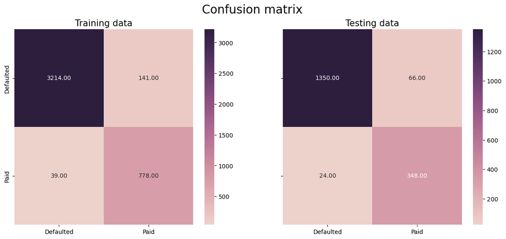

```python
# Plotting confusion matrix of training and testing data
conf_matrix(rf_clf_tuned)
```

```python
# Checking performance of tuned model on training data
model_performance(rf_clf_tuned, x_train, y_train)
```

|  | Precision | Recall | Accuracy | F1-score |
| --- | --- | --- | --- | --- |
| Score | 0.917292 | 0.955119 | 0.956855 | 0.896313 |

```python
# Checking performance on the testing data
rf_tuned_test = model_performance(rf_clf_tuned, x_test, y_test)
rf_tuned_test
```

|  | Precision | Recall | Accuracy | F1-score |
| --- | --- | --- | --- | --- |
| Score | 0.911556 | 0.944437 | 0.949664 | 0.885496 |

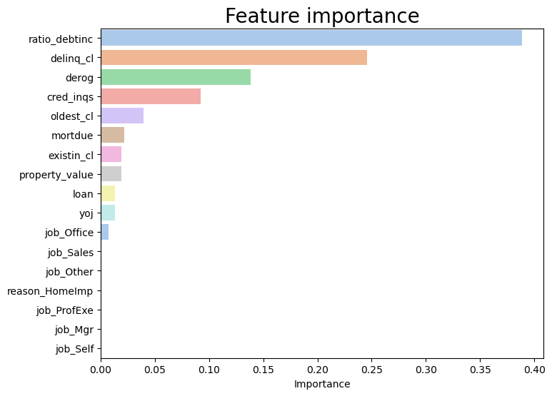

```python
# Getting importances
importance(rf_clf_tuned)
```

### Observations:

- As expected, performance on training data has decreased, nevertheless the performance on both datasets are closer. The recall score on training and testing datasets are 0.95 and 0.94, respectively.
- Once again, the model agrees on the top 5 important features being debt-to-income ratio, delinquent credit lines, derogatory reports, credit inquiries and oldest credit, respectively.

## Logistic regression

As the final predicting model, it is constructed a logistic regression model. First, it is scaled the since the different scales in variables directly affects the performance of logistic regression.

```python
# Separate independent and dependent variables
yl = ddf['defaulted'].copy()
xl = ddf.copy().drop(columns = ['defaulted'])

# Setting Scikit learn method StandardScaler
sc = StandardScaler()

# Scaling data from independent variables
x_scaled = sc.fit_transform(xl)
x_scaled = pd.DataFrame(x_scaled, columns = xl.columns)

# Split scaled data into training and testing (0.7,0.3 ratio)
xl_train, xl_test, yl_train, yl_test = train_test_split(x_scaled,yl, test_size=0.3, shuffle=True, random_state=1, stratify=yl)
```

```python
# Setting the logistic regression algorithm
lg = LogisticRegression(random_state=1, class_weight= {0: 0.2, 1: 0.8})

# fitting the model to training data
lg.fit(xl_train, yl_train)
```

```
LogisticRegression(class_weight={0: 0.2, 1: 0.8}, random_state=1)
```

```python
# showing parameter for the logistic regression model
lg.get_params()
```

```
{'C': 1.0,
 'class_weight': {0: 0.2, 1: 0.8},
 'dual': False,
 'fit_intercept': True,
 'intercept_scaling': 1,
 'l1_ratio': None,
 'max_iter': 100,
 'multi_class': 'auto',
 'n_jobs': None,
 'penalty': 'l2',
 'random_state': 1,
 'solver': 'lbfgs',
 'tol': 0.0001,
 'verbose': 0,
 'warm_start': False}
```

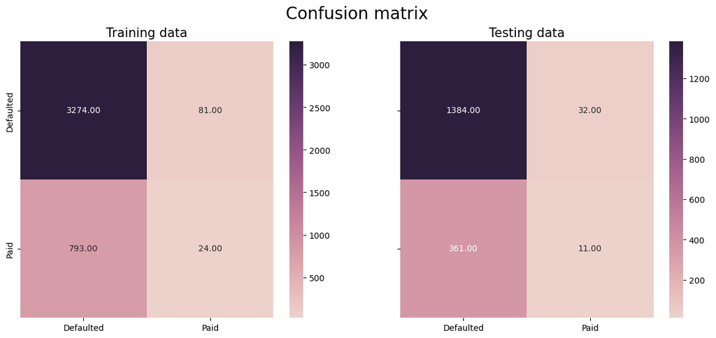

```python
# Plotting confusion matrix of training and testing data
conf_matrix(lg)
```

```python
# Checking performance of tuned model on training data
model_performance(lg, xl_train, yl_train)
```

|  | Precision | Recall | Accuracy | F1-score |
| --- | --- | --- | --- | --- |
| Score | 0.811515 | 0.84617 | 0.88303 | 0.727982 |

```python
# Checking performance of tuned model on testing data
lg_test = model_performance(lg, xl_test, yl_test)
lg_test
```

|  | Precision | Recall | Accuracy | F1-score |
| --- | --- | --- | --- | --- |
| Score | 0.812189 | 0.842882 | 0.88311 | 0.726081 |

We can notice that the model with default settings is not overfitting, although it is significantly less accurate than previous predictive models.

**Let's print the coefficients for the model.**

```python
# setting a dummy variable with column names
cols = xl.columns
# getting logistic regression model coefficients
coef_lg = lg.coef_
# creating a dataframe with coefficients
pd.DataFrame(coef_lg,columns = cols, index=['Coefficients']).T.sort_values(by = 'Coefficients', ascending = False)
```

|  | Coefficients |
| --- | --- |
| delinq_cl | 3.547198 |
| derog | 1.887011 |
| ratio_debtinc | 1.349587 |
| cred_inqs | 0.295202 |
| job_Sales | 0.171637 |
| job_ProfExe | 0.155875 |
| property_value | 0.091147 |
| reason_HomeImp | 0.064497 |
| job_Self | 0.039616 |
| job_Mgr | 0.005349 |
| job_Other | 0.001635 |
| yoj | -0.139003 |
| loan | -0.158430 |
| mortdue | -0.231254 |
| job_Office | -0.264001 |
| existin_cl | -0.378805 |
| oldest_cl | -0.545797 |

### Logistics regression hyperparameter tuning

In order to refine the model, maximum iterations and the solver are chosen to be refined.

```python
# Adjusting class weights on the classifier
lg_tuned = LogisticRegression(random_state=1, class_weight= {0: 0.2, 1: 0.8})

# Grid of hyperparameters to chose
parameter_rf = {
        'max_iter':[250,270,300],
        'solver': ['lbfgs', 'liblinear', 'newton-cg', 'newton-cholesky', 'sag', 'saga'],
        }

# Scoring to compare the parameter combinations. Recall for class 1 in this case
scorer = metrics.make_scorer(recall_score, pos_label=1)

# Running Grid search
grid_obj_log = GridSearchCV(lg_tuned, parameter_rf, scoring=recall_score, cv=7)

grid_obj_log = grid_obj_log.fit(xl_train, yl_train)

# Select the best estimator i.e. the random forest settings with highest recall score
lg_tuned = grid_obj_log.best_estimator_

# Fit the training data to the best estimator
lg_tuned.fit(xl_train, yl_train)
```

```
LogisticRegression(class_weight={0: 0.2, 1: 0.8}, max_iter=250, random_state=1)
```

```python
# showing parameter from tuned random forest
lg_tuned.get_params()
```

```
{'C': 1.0,
 'class_weight': {0: 0.2, 1: 0.8},
 'dual': False,
 'fit_intercept': True,
 'intercept_scaling': 1,
 'l1_ratio': None,
 'max_iter': 250,
 'multi_class': 'auto',
 'n_jobs': None,
 'penalty': 'l2',
 'random_state': 1,
 'solver': 'lbfgs',
 'tol': 0.0001,
 'verbose': 0,
 'warm_start': False}
```

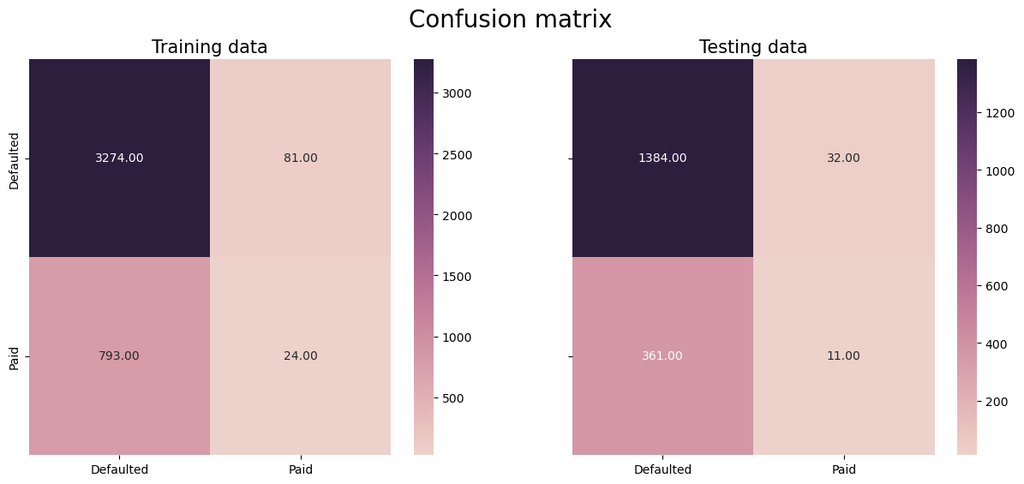

```python
# Plotting confusion matrix of training and testing data
conf_matrix(lg_tuned)
```

```python
# Checking performance of tuned model on training data
model_performance(lg_tuned, xl_train, yl_train)
```

|  | Precision | Recall | Accuracy | F1-score |
| --- | --- | --- | --- | --- |
| Score | 0.811515 | 0.84617 | 0.88303 | 0.727982 |

```python
# Checking performance of tuned model on testing data
lg_tun = model_performance(lg_tuned, xl_test, yl_test)
lg_tun
```

|  | Precision | Recall | Accuracy | F1-score |
| --- | --- | --- | --- | --- |
| Score | 0.812189 | 0.842882 | 0.88311 | 0.726081 |

```python
# setting a dummy variable with column names
cols = xl.columns
# getting logistic regression model coefficients
coef_lg = lg_tuned.coef_
# creating a dataframe with coefficients
pd.DataFrame(coef_lg,columns = cols, index=['Coefficients']).T.sort_values(by = 'Coefficients', ascending = False)
```

|  | Coefficients |
| --- | --- |
| delinq_cl | 3.547198 |
| derog | 1.887011 |
| ratio_debtinc | 1.349587 |
| cred_inqs | 0.295202 |
| job_Sales | 0.171637 |
| job_ProfExe | 0.155875 |
| property_value | 0.091147 |
| reason_HomeImp | 0.064497 |
| job_Self | 0.039616 |
| job_Mgr | 0.005349 |
| job_Other | 0.001635 |
| yoj | -0.139003 |
| loan | -0.158430 |
| mortdue | -0.231254 |
| job_Office | -0.264001 |
| existin_cl | -0.378805 |
| oldest_cl | -0.545797 |

## Model performance comparison

Once that all models have been trained, it is time to compare their overall performance. Altoguh we have computed precision, accuracy, f1 score and recall, we are mostly interested in the last one since we have previously stated that the goal was to maximize the recall score.

```python
# Concatenating metrics from all models
models_test_comp_df = pd.concat([dtree_test.T, dtree_tuned_test.T, rf_test.T, rf_tuned_test.T, lg_test.T, lg_tun.T], axis = 1)
# setting columns names
models_test_comp_df.columns = ["Decision Tree classifier",
    "Tuned Decision Tree classifier",
    "Random Forest classifier",
    "Tuned Random Forest classifier",
    'Logistic Regression',
    'Tuned logistic regression']
# printing model comparisson
models_test_comp_df
```

|  | Decision Tree classifier | Tuned Decision Tree classifier | Random Forest classifier | Tuned Random Forest classifier | Logistic Regression | Tuned logistic regression |
| --- | --- | --- | --- | --- | --- | --- |
| Precision | 0.971625 | 0.858660 | 0.989538 | 0.911556 | 0.812189 | 0.812189 |
| Recall | 0.968813 | 0.918296 | 0.964701 | 0.944437 | 0.842882 | 0.842882 |
| Accuracy | 0.980425 | 0.916107 | 0.984899 | 0.949664 | 0.883110 | 0.883110 |
| F1-score | 0.952767 | 0.820574 | 0.962448 | 0.885496 | 0.726081 | 0.726081 |

The specific parameters of the model are printed below.

```python
# Tuned random forest parameters
rf_clf_tuned.get_params()
```

```
{'bootstrap': True,
 'ccp_alpha': 0.0,
 'class_weight': {0: 0.2, 1: 0.8},
 'criterion': 'entropy',
 'max_depth': None,
 'max_features': 'auto',
 'max_leaf_nodes': 15,
 'max_samples': None,
 'min_impurity_decrease': 0.0,
 'min_samples_leaf': 1,
 'min_samples_split': 2,
 'min_weight_fraction_leaf': 0.0,
 'n_estimators': 340,
 'n_jobs': None,
 'oob_score': False,
 'random_state': 1,
 'verbose': 0,
 'warm_start': False}
```

## Business insights and recommendations

- The bank should be careful with clients that have a greater debt-to-income ratio since it is the most important feature when predicting if the client will default on its loan. This outcome was expected from the exploratory data analysis as it was pointed that the distributions of debt-to-income for clients who defaulted on its loan was siginificantly higher than those who repaid the loan.
- Moreover, it makes sense that having a high debt to income ratio will negativily impact the possibility of a person to pay all it debts and loans.
- Another two important features to take in consideration is the number of derogatory reports and delinquent credit lines. As expected, this variables shows a defaulting pattern since nearly 55% of people with at least one derogatory report or a delinquent credit line defaulted on its loan.
- On the ohter hand, people with oldest credit lines tends to not default on its loan. This behaviour shows that people who can pay their debts tends to mantain their credit lines active.
- Finally, the specific profession of the client does not seems to be important to predict whether the client will default on its loan.

**Conclusions:**